## sunsky

# Sunsky

# Image classifier for the SVHN dataset

## 目录

- Capstone Project
  - Image classifier for the SVHN dataset
    - Instructions
    - How to submit
    - Let’s get started!
  - 1. Inspect and preprocess the dataset
  - 2. MLP neural network classifier
  - 3. CNN neural network classifier
  - 4. Get model predictions

# Capstone Project

## Image classifier for the SVHN dataset

### Instructions

In this notebook, you will create a neural network that classifies real-world images digits. You will use concepts from throughout this course in building, training, testing, validating and saving your Tensorflow classifier model.

This project is peer-assessed. Within this notebook you will find instructions in each section for how to complete the project. Pay close attention to the instructions as the peer review will be carried out according to a grading rubric that checks key parts of the project instructions. Feel free to add extra cells into the notebook as required.

### How to submit

When you have completed the Capstone project notebook, you will submit a pdf of the notebook for peer review. First ensure that the notebook has been fully executed from beginning to end, and all of the cell outputs are visible. This is important, as the grading rubric depends on the reviewer being able to view the outputs of your notebook. Save the notebook as a pdf (File -> Download as -> PDF via LaTeX). You should then submit this pdf for review.

### Let's get started!

We'll start by running some imports, and loading the dataset. For this project you are free to make further imports throughout the notebook as you wish.

```python
import tensorflow as tf
from scipy.io import loadmat

import matplotlib.pyplot as plt
import numpy as np
```

[figure not shown]

For the capstone project, you will use the [SVHN dataset](http://ufldl.stanford.edu/housenumbers/). This is an image dataset of over 600,000 digit images in all, and is a harder dataset than MNIST as the numbers appear in the context of natural scene images. SVHN is obtained from house numbers in Google Street View images.

- Y. Netzer, T. Wang, A. Coates, A. Bissacco, B. Wu and A. Y. Ng. "Reading Digits in Natural Images with Unsupervised Feature Learning". NIPS Workshop on Deep Learning and Unsupervised Feature Learning, 2011.

Your goal is to develop an end-to-end workflow for building, training, validating, evaluating and saving a neural network that classifies a real-world image into one of ten classes.

```python
# Run this cell to load the dataset

train = loadmat('data/train_32x32.mat')
test = loadmat('data/test_32x32.mat')
```

Both `train` and `test` are dictionaries with keys `X` and `y` for the input images and labels respectively.

```python
train["X"][0].shape
```

```
(32, 3, 73257)
```

```python
test["y"].shape
```

```
(26032, 1)
```

```python
a  = np.where(test["y"]<10, test["y"], 0)
a = np.unique(a, return_counts=True)
a
```

```
(array([0, 1, 2, 3, 4, 5, 6, 7, 8, 9], dtype=uint8),
 array([1744, 5099, 4149, 2882, 2523, 2384, 1977, 2019, 1660, 1595]))
```

## 1. Inspect and preprocess the dataset

- Extract the training and testing images and labels separately from the train and test dictionaries loaded for you.
- Select a random sample of images and corresponding labels from the dataset (at least 10), and display them in a figure.
- Convert the training and test images to grayscale by taking the average across all colour channels for each pixel. *Hint: retain the channel dimension, which will now have size 1.*
- Select a random sample of the grayscale images and corresponding labels from the dataset (at least 10), and display them in a figure.

```python
train_data = np.transpose(train["X"], (3,0,1,2))
train_targets = np.where(train["y"]<10, train["y"], 0)
test_data = np.transpose(test["X"], (3,0,1,2))
test_targets = np.where(test["y"]<10, test["y"], 0)
```

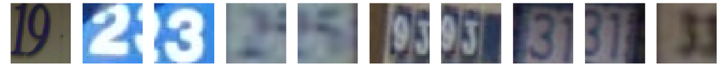

```python
fig=plt.figure(figsize=(32, 32))
columns = 10
rows = 1
for i in range(1, columns*rows +1):
    fig.add_subplot(rows, columns, i)
    plt.imshow(train_data[i])
    plt.axis("off")
plt.show()
```

```python
train_data_gray = np.mean(train_data, axis=-1)
test_data_gray = np.mean(test_data, axis=-1)
```

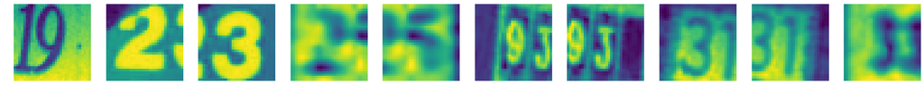

```python
fig=plt.figure(figsize=(32, 32))
columns = 10
rows = 1
for i in range(1, columns*rows +1):
    fig.add_subplot(rows, columns, i)
    plt.imshow(train_data_gray[i])
    plt.axis("off")
plt.show()
```

## 2. MLP neural network classifier

- Build an MLP classifier model using the Sequential API. Your model should use only Flatten and Dense layers, with the final layer having a 10-way softmax output.
- You should design and build the model yourself. Feel free to experiment with different MLP architectures. *Hint: to achieve a reasonable accuracy you won't need to use more than 4 or 5 layers.*
- Print out the model summary (using the summary() method)
- Compile and train the model (we recommend a maximum of 30 epochs), making use of both training and validation sets during the training run.
- Your model should track at least one appropriate metric, and use at least two callbacks during training, one of which should be a ModelCheckpoint callback.
- As a guide, you should aim to achieve a final categorical cross entropy training loss of less than 1.0 (the validation loss might be higher).
- Plot the learning curves for loss vs epoch and accuracy vs epoch for both training and validation sets.
- Compute and display the loss and accuracy of the trained model on the test set.

```python
from tensorflow.keras.models import Sequential
from tensorflow.keras.layers import Flatten, Dense
```

```python
def get_new_model(input_shape):
    model = Sequential([
        Flatten(input_shape=input_shape),
        Dense(units=128, activation="relu"),
        Dense(units=128, activation="relu"),
        Dense(units=128, activation="relu"),
        Dense(units=64, activation="relu"),
        Dense(units=64, activation="relu"),
        Dense(units=64, activation="relu"),

        Dense(units=10,use_bias=True, activation="softmax",bias_initializer='ones')
    ])
    model.compile(optimizer="adam", loss="sparse_categorical_crossentropy",metrics=["acc"])
    return model
```

```python
mlp_model = get_new_model(train_data_gray[0].shape)
mlp_model.summary()
```

```
Model: "sequential_1"
_________________________________________________________________
Layer (type)                 Output Shape              Param #
=================================================================
flatten_1 (Flatten)          (None, 1024)              0
_________________________________________________________________
dense_7 (Dense)              (None, 128)               131200
_________________________________________________________________
dense_8 (Dense)              (None, 128)               16512
_________________________________________________________________
dense_9 (Dense)              (None, 128)               16512
_________________________________________________________________
dense_10 (Dense)             (None, 64)                8256
_________________________________________________________________
dense_11 (Dense)             (None, 64)                4160
_________________________________________________________________
dense_12 (Dense)             (None, 64)                4160
_________________________________________________________________
dense_13 (Dense)             (None, 10)                650
=================================================================
Total params: 181,450
Trainable params: 181,450
Non-trainable params: 0
_________________________________________________________________
```

```python
checkpoint_best_path = "model_checkpoint_best/checkpoint"
checkpoint_best = tf.keras.callbacks.ModelCheckpoint(
    filepath=checkpoint_best_path,
    save_weights_only=True,
    save_best_only=True,
    save_freq="epoch",
    verbose=2
)
earlystoping = tf.keras.callbacks.EarlyStopping(min_delta=0.001,patience=5)
class training_callback(tf.keras.callbacks.Callback):
    def on_train_begin(self, logs=None):
        print("Start training....")
    def on_train_end(self, logs=None):
        print("Finished training!")
```

```python
history = mlp_model.fit(train_data_gray, train_targets, validation_split=0.2, epochs=30, batch_size=512, verbose=2,
                    callbacks=[checkpoint_best,earlystoping, training_callback()])
```

```
Train on 58605 samples, validate on 14652 samples
Start training....

Epoch 00001: val_loss improved from inf to 2.31268, saving model to model_checkpoint_best/checkpoint
58605/58605 - 15s - loss: 4.9295 - acc: 0.1375 - val_loss: 2.3127 - val_acc: 0.1582

Epoch 00002: val_loss improved from 2.31268 to 2.29652, saving model to model_checkpoint_best/checkpoint
58605/58605 - 12s - loss: 2.2981 - acc: 0.1764 - val_loss: 2.2965 - val_acc: 0.1923

Epoch 00003: val_loss improved from 2.29652 to 2.22045, saving model to model_checkpoint_best/checkpoint
58605/58605 - 11s - loss: 2.2296 - acc: 0.2041 - val_loss: 2.2204 - val_acc: 0.1942

Epoch 00004: val_loss improved from 2.22045 to 2.02536, saving model to model_checkpoint_best/checkpoint
58605/58605 - 12s - loss: 2.1127 - acc: 0.2650 - val_loss: 2.0254 - val_acc: 0.3120

Epoch 00005: val_loss improved from 2.02536 to 1.79277, saving model to model_checkpoint_best/checkpoint
58605/58605 - 12s - loss: 1.8875 - acc: 0.3522 - val_loss: 1.7928 - val_acc: 0.3871

Epoch 00006: val_loss improved from 1.79277 to 1.66023, saving model to model_checkpoint_best/checkpoint
58605/58605 - 12s - loss: 1.7137 - acc: 0.4130 - val_loss: 1.6602 - val_acc: 0.4245

Epoch 00007: val_loss improved from 1.66023 to 1.48898, saving model to model_checkpoint_best/checkpoint
58605/58605 - 12s - loss: 1.5643 - acc: 0.4673 - val_loss: 1.4890 - val_acc: 0.5033

Epoch 00008: val_loss improved from 1.48898 to 1.40066, saving model to model_checkpoint_best/checkpoint
58605/58605 - 12s - loss: 1.4500 - acc: 0.5164 - val_loss: 1.4007 - val_acc: 0.5422

Epoch 00009: val_loss improved from 1.40066 to 1.31677, saving model to model_checkpoint_best/checkpoint
58605/58605 - 12s - loss: 1.3507 - acc: 0.5580 - val_loss: 1.3168 - val_acc: 0.5691

Epoch 00010: val_loss improved from 1.31677 to 1.29341, saving model to model_checkpoint_best/checkpoint
58605/58605 - 12s - loss: 1.2597 - acc: 0.5926 - val_loss: 1.2934 - val_acc: 0.5814

Epoch 00011: val_loss improved from 1.29341 to 1.22135, saving model to model_checkpoint_best/checkpoint
58605/58605 - 12s - loss: 1.2089 - acc: 0.6117 - val_loss: 1.2214 - val_acc: 0.6146

Epoch 00012: val_loss improved from 1.22135 to 1.21198, saving model to model_checkpoint_best/checkpoint
58605/58605 - 12s - loss: 1.1332 - acc: 0.6400 - val_loss: 1.2120 - val_acc: 0.6176

Epoch 00013: val_loss improved from 1.21198 to 1.16683, saving model to model_checkpoint_best/checkpoint
```

[output cut: 35 more lines]

```
Epoch 00025: val_loss did not improve from 0.87524
58605/58605 - 12s - loss: 0.8235 - acc: 0.7473 - val_loss: 0.9086 - val_acc: 0.7213

Epoch 00026: val_loss did not improve from 0.87524
58605/58605 - 12s - loss: 0.8111 - acc: 0.7508 - val_loss: 1.0186 - val_acc: 0.6868

Epoch 00027: val_loss did not improve from 0.87524
58605/58605 - 12s - loss: 0.8081 - acc: 0.7518 - val_loss: 0.8770 - val_acc: 0.7317

Epoch 00028: val_loss did not improve from 0.87524
58605/58605 - 12s - loss: 0.7933 - acc: 0.7557 - val_loss: 0.9535 - val_acc: 0.7065

Epoch 00029: val_loss did not improve from 0.87524
58605/58605 - 12s - loss: 0.7733 - acc: 0.7621 - val_loss: 0.8862 - val_acc: 0.7366
Finished training!
```

```python
import pandas as pd
```

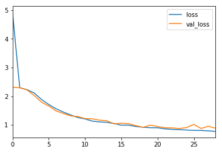

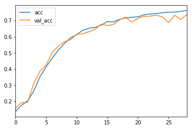

```python
df = pd.DataFrame(history.history)
df.plot(y=["loss","val_loss"])
df.plot(y=["acc","val_acc"])
```

```python
mlp_model.evaluate(test_data_gray, test_targets, verbose=0)
```

```
[0.9823977961339464, 0.71734786]
```

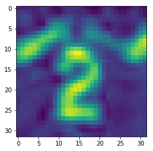

```python
plt.imshow(test_data_gray[1024])
```

```python
np.argmax(mlp_model.predict(test_data_gray[1024][np.newaxis,...]))
```

```
2
```

## 3. CNN neural network classifier

- Build a CNN classifier model using the Sequential API. Your model should use the Conv2D, MaxPool2D, BatchNormalization, Flatten, Dense and Dropout layers. The final layer should again have a 10-way softmax output.
- You should design and build the model yourself. Feel free to experiment with different CNN architectures. *Hint: to achieve a reasonable accuracy you won't need to use more than 2 or 3 convolutional layers and 2 fully connected layers.)*
- The CNN model should use fewer trainable parameters than your MLP model.
- Compile and train the model (we recommend a maximum of 30 epochs), making use of both training and validation sets during the training run.
- Your model should track at least one appropriate metric, and use at least two callbacks during training, one of which should be a ModelCheckpoint callback.
- You should aim to beat the MLP model performance with fewer parameters!
- Plot the learning curves for loss vs epoch and accuracy vs epoch for both training and validation sets.
- Compute and display the loss and accuracy of the trained model on the test set.

```python
from tensorflow.keras.layers import Conv2D, MaxPool2D, BatchNormalization, Flatten, Dense, Dropout
```

```python
def get_cnn_model(input_shape,wd,reg):
    model =  Sequential([
        Conv2D(filters=16, kernel_size=(3,3),activation="relu",input_shape=input_shape,kernel_regularizer=tf.keras.regularizers.l2(reg)),
        Conv2D(filters=8, kernel_size=(3,3), activation="relu"),
        MaxPool2D(pool_size=(3,3)),
        Dropout(wd),
        Dense(units=32, activation="relu"),
        BatchNormalization(),
        Dense(units=32, activation="relu"),
        Flatten(),
        Dense(units=10, activation="softmax")

    ])
    model.compile(optimizer="adam", loss="sparse_categorical_crossentropy",metrics=["acc"])
    return model
```

```python
cnn_model = get_cnn_model(train_data_gray[0][...,np.newaxis].shape, 0.5, 0.01)
cnn_model.summary()
```

```
Model: "sequential_2"
_________________________________________________________________
Layer (type)                 Output Shape              Param #
=================================================================
conv2d (Conv2D)              (None, 30, 30, 16)        160
_________________________________________________________________
conv2d_1 (Conv2D)            (None, 28, 28, 8)         1160
_________________________________________________________________
max_pooling2d (MaxPooling2D) (None, 9, 9, 8)           0
_________________________________________________________________
dropout (Dropout)            (None, 9, 9, 8)           0
_________________________________________________________________
dense_14 (Dense)             (None, 9, 9, 32)          288
_________________________________________________________________
batch_normalization (BatchNo (None, 9, 9, 32)          128
_________________________________________________________________
dense_15 (Dense)             (None, 9, 9, 32)          1056
_________________________________________________________________
flatten_2 (Flatten)          (None, 2592)              0
_________________________________________________________________
dense_16 (Dense)             (None, 10)                25930
=================================================================
Total params: 28,722
Trainable params: 28,658
Non-trainable params: 64
_________________________________________________________________
```

```python
checkpoint_best_cnn_path = "model_checkpoint_best_cnn/checkpoint"
checkpoint_best = tf.keras.callbacks.ModelCheckpoint(
    filepath=checkpoint_best_cnn_path,
    save_weights_only=True,
    save_best_only=True,
    save_freq="epoch",
    verbose=2
)
earlystoping = tf.keras.callbacks.EarlyStopping(min_delta=0.001,patience=5)
class training_callback(tf.keras.callbacks.Callback):
    def on_train_begin(self, logs=None):
        print("Start training....")
    def on_train_end(self, logs=None):
        print("Finished training!")
```

```python
history = cnn_model.fit(train_data_gray[...,np.newaxis], train_targets, validation_split=0.2, epochs=30, batch_size=512, verbose=1,
                    callbacks=[checkpoint_best, earlystoping, training_callback()])
```

```
Train on 58605 samples, validate on 14652 samples
Start training....
Epoch 00001: val_loss improved from inf to 1.57061, saving model to model_checkpoint_best_cnn/checkpoint
Epoch 00002: val_loss improved from 1.57061 to 1.03491, saving model to model_checkpoint_best_cnn/checkpoint
Epoch 00003: val_loss improved from 1.03491 to 0.87107, saving model to model_checkpoint_best_cnn/checkpoint
Epoch 00004: val_loss improved from 0.87107 to 0.75893, saving model to model_checkpoint_best_cnn/checkpoint
Epoch 00005: val_loss did not improve from 0.75893
Epoch 00006: val_loss improved from 0.75893 to 0.73237, saving model to model_checkpoint_best_cnn/checkpoint
Epoch 00007: val_loss improved from 0.73237 to 0.67818, saving model to model_checkpoint_best_cnn/checkpoint
Epoch 00008: val_loss did not improve from 0.67818
Epoch 00009: val_loss improved from 0.67818 to 0.67764, saving model to model_checkpoint_best_cnn/checkpoint
Epoch 00010: val_loss did not improve from 0.67764
Epoch 00011: val_loss improved from 0.67764 to 0.63230, saving model to model_checkpoint_best_cnn/checkpoint
Epoch 00012: val_loss did not improve from 0.63230
Epoch 00013: val_loss did not improve from 0.63230
Epoch 00014: val_loss improved from 0.63230 to 0.61327, saving model to model_checkpoint_best_cnn/checkpoint
Epoch 00015: val_loss did not improve from 0.61327
Epoch 00016: val_loss did not improve from 0.61327
Epoch 00017: val_loss improved from 0.61327 to 0.61224, saving model to model_checkpoint_best_cnn/checkpoint
Epoch 00018: val_loss did not improve from 0.61224
Epoch 00019: val_loss improved from 0.61224 to 0.60660, saving model to model_checkpoint_best_cnn/checkpoint
Epoch 00020: val_loss did not improve from 0.60660
Epoch 00021: val_loss did not improve from 0.60660
Epoch 00022: val_loss did not improve from 0.60660
Epoch 00023: val_loss improved from 0.60660 to 0.60656, saving model to model_checkpoint_best_cnn/checkpoint
Epoch 00024: val_loss improved from 0.60656 to 0.60267, saving model to model_checkpoint_best_cnn/checkpoint
Epoch 00025: val_loss did not improve from 0.60267
Epoch 00026: val_loss did not improve from 0.60267
Epoch 00027: val_loss improved from 0.60267 to 0.60197, saving model to model_checkpoint_best_cnn/checkpoint
Epoch 00028: val_loss did not improve from 0.60197
Epoch 00029: val_loss did not improve from 0.60197
Finished training!
```

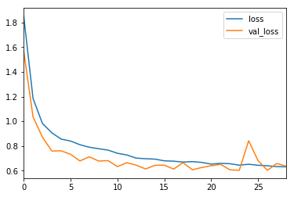

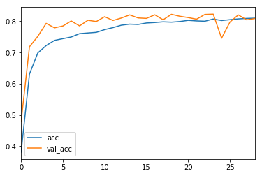

```python
df = pd.DataFrame(history.history)
df.plot(y=["loss","val_loss"])
df.plot(y=["acc","val_acc"])
```

```python
del mlp_model, cnn_model
```

## 4. Get model predictions

- Load the best weights for the MLP and CNN models that you saved during the training run.
- Randomly select 5 images and corresponding labels from the test set and display the images with their labels.
- Alongside the image and label, show each model’s predictive distribution as a bar chart, and the final model prediction given by the label with maximum probability.

```python
mlp_model = get_new_model(train_data_gray[0].shape)
cnn_model = get_cnn_model(train_data_gray[0][...,np.newaxis].shape, 0.5, 0.001)
```

```python
mlp_model.load_weights("model_checkpoint_best/checkpoint")
mlp_model.summary()
```

```
Model: "sequential_3"
_________________________________________________________________
Layer (type)                 Output Shape              Param #
=================================================================
flatten_3 (Flatten)          (None, 1024)              0
_________________________________________________________________
dense_17 (Dense)             (None, 128)               131200
_________________________________________________________________
dense_18 (Dense)             (None, 128)               16512
_________________________________________________________________
dense_19 (Dense)             (None, 128)               16512
_________________________________________________________________
dense_20 (Dense)             (None, 64)                8256
_________________________________________________________________
dense_21 (Dense)             (None, 64)                4160
_________________________________________________________________
dense_22 (Dense)             (None, 64)                4160
_________________________________________________________________
dense_23 (Dense)             (None, 10)                650
=================================================================
Total params: 181,450
Trainable params: 181,450
Non-trainable params: 0
_________________________________________________________________
```

```python
cnn_model.load_weights("model_checkpoint_best_cnn/checkpoint")
cnn_model.summary()
```

```
Model: "sequential_4"
_________________________________________________________________
Layer (type)                 Output Shape              Param #
=================================================================
conv2d_2 (Conv2D)            (None, 30, 30, 16)        160
_________________________________________________________________
conv2d_3 (Conv2D)            (None, 28, 28, 8)         1160
_________________________________________________________________
max_pooling2d_1 (MaxPooling2 (None, 9, 9, 8)           0
_________________________________________________________________
dropout_1 (Dropout)          (None, 9, 9, 8)           0
_________________________________________________________________
dense_24 (Dense)             (None, 9, 9, 32)          288
_________________________________________________________________
batch_normalization_1 (Batch (None, 9, 9, 32)          128
_________________________________________________________________
dense_25 (Dense)             (None, 9, 9, 32)          1056
_________________________________________________________________
flatten_4 (Flatten)          (None, 2592)              0
_________________________________________________________________
dense_26 (Dense)             (None, 10)                25930
=================================================================
Total params: 28,722
Trainable params: 28,658
Non-trainable params: 64
_________________________________________________________________
```

```python
random_idx = np.random.choice(test_data.shape[0], 5)
random_test_data_gray = test_data_gray[random_idx, ...]
random_test_data = test_data_gray[random_idx, ...]
random_test_targets = test_targets[random_idx,...]
```

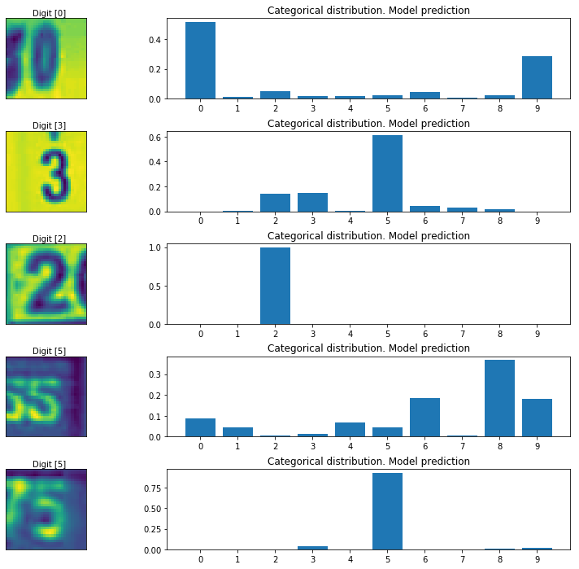

```python
mlp_predictions = mlp_model.predict(random_test_data_gray)
fig, axes = plt.subplots(5, 2, figsize=(16, 12))
fig.subplots_adjust(hspace=0.4,wspace=-0.2)
for i, (prediction, image, label) in enumerate(zip(mlp_predictions, random_test_data, random_test_targets)):
    axes[i, 0].imshow(np.squeeze(image))
    axes[i, 0].get_xaxis().set_visible(False)
    axes[i, 0].get_yaxis().set_visible(False)
    axes[i, 0].text(10, -1.5, f"Digit {label}")
    axes[i, 1].bar(np.arange(0, 10), prediction)
    axes[i, 1].set_xticks(np.arange(0, 10))
    axes[i, 1].set_title("Categorical distribution. Model prediction")
plt.show()
```

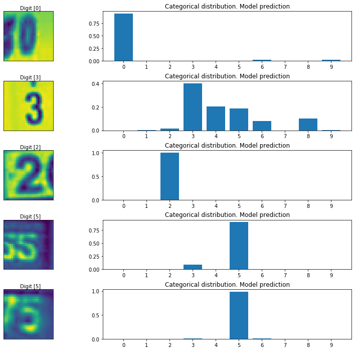

```python
cnn_predictions = cnn_model.predict(random_test_data_gray[...,np.newaxis])
fig, axes = plt.subplots(5, 2, figsize=(16, 12))
fig.subplots_adjust(hspace=0.4,wspace=-0.2)
for i, (prediction, image, label) in enumerate(zip(cnn_predictions, random_test_data, random_test_targets)):
    axes[i, 0].imshow(np.squeeze(image))
    axes[i, 0].get_xaxis().set_visible(False)
    axes[i, 0].get_yaxis().set_visible(False)
    axes[i, 0].text(10, -1.5, f"Digit {label}")
    axes[i, 1].bar(np.arange(0, 10), prediction)
    axes[i, 1].set_xticks(np.arange(0, 10))
    axes[i, 1].set_title("Categorical distribution. Model prediction")
plt.show()
```